# Final results

Nhat Le

10/3/2019

### Descriptive analysis

#### Table 1. Summary of demographics and baseline characteristics of hospital admission of the study population

|  |  |  | Measles (N=4419) |  | 2 years before MeV (N=1370) |  | After MeV (N=961) |
| --- | --- | --- | --- | --- | --- | --- | --- |
|  | Characteristic | n | Summary statistic | n | Summary statistic | n | Summary statistic |
|  | Number of patients | 4419 |  | 988 |  | 695 |  |
|  | sex | 4419 |  | 988 |  | 695 |  |
|  | - female |  | 1880/4419 (43%) |  | 357/988 (36%) |  | 275/695 (40%) |
|  | - male |  | 2539/4419 (57%) |  | 631/988 (64%) |  | 420/695 (60%) |
|  | age | 4419 | 1.45(0.80,3.02) | 1370 | 0.76(0.48,1.32) | 961 | 1.48(1.02,2.24) |
|  | outcome | 4419 |  | 1370 |  | 961 |  |
|  | - dead |  | 3/4419 (0%) |  | 0/1370 (0%) |  | 2/961 (0%) |
|  | - discharged |  | 4342/4419 (98%) |  | 1366/1370 (100%) |  | 850/961 (88%) |
|  | - presumably.worse |  | 35/4419 (1%) |  | 0/1370 (0%) |  | 8/961 (1%) |
|  | - unknown |  | 39/4419 (1%) |  | 4/1370 (0%) |  | 101/961 (11%) |

*N* is the number of hospital admissions. * Please, remove the dominator number in the table!

#### Table S1: Summary table of reason for hospital admission

| major | sub_chapter | type_ID | two_years_before_MeV_below5_years_olds | two_years_before_MeV_5to15_years_old | below1_year_after_MeV_below5_years_old | below1_year_after_MeV_5to15_years_old | above1_year_after_MeV_below5_year_old | above1_year_after_MeV_5to15_years_old |
| --- | --- | --- | --- | --- | --- | --- | --- | --- |
| Infectious gastroenteritis and colitis, unspecified | Intestinal Infectious Diseases | no NTD | 183 | 0 | 85 | 4 | 10 | 1 |
| Other bacterial intestinal infections | Intestinal Infectious Diseases | no NTD | 21 | 0 | 12 | 0 | 4 | 0 |
| Shigellosis | Intestinal Infectious Diseases | no NTD | 16 | 0 | 4 | 0 | 1 | 0 |
| Amebiasis | Intestinal Infectious Diseases | no NTD | 0 | 0 | 1 | 0 | 0 | 0 |
| Tuberculosis | Tuberculosis | no NTD | 1 | 0 | 0 | 1 | 0 | 0 |
| Other sepsis | Other Bacterial Diseases | no NTD | 3 | 0 | 1 | 1 | 0 | 0 |
| Whooping cough | Other Bacterial Diseases | no NTD | 1 | 0 | 0 | 0 | 0 | 0 |
| Viral meningitis | Viral And Prion Infections Of The Central Nervous System | no NTD | 0 | 0 | 0 | 1 | 1 | 0 |
| Dengue | Arthropod-Borne Viral Fevers And Viral Hemorrhagic Fevers | NTD | 23 | 5 | 10 | 0 | 8 | 7 |
| Unspecified viral hemorrhagic fever | Arthropod-Borne Viral Fevers And Viral Hemorrhagic Fevers | no NTD | 7 | 0 | 2 | 1 | 2 | 1 |
| Oth viral infect with skin and mucous membrane lesions, NEC | Viral Infections Characterized By Skin And Mucous Membrane Lesions | no NTD | 111 | 0 | 66 | 0 | 18 | 0 |
| Unsp viral infection with skin and mucous membrane lesions | Viral Infections Characterized By Skin And Mucous Membrane Lesions | no NTD | 6 | 0 | 6 | 0 | 0 | 0 |
| Varicella [chickenpox] | Viral Infections Characterized By Skin And Mucous Membrane Lesions | no NTD | 0 | 0 | 4 | 0 | 0 | 0 |
| Zoster [herpes zoster] | Viral Infections Characterized By Skin And Mucous Membrane Lesions | no NTD | 0 | 0 | 1 | 0 | 0 | 0 |
| Viral infection of unspecified site | Other Viral Diseases | no NTD | 93 | 1 | 37 | 1 | 13 | 3 |
| Cytomegaloviral disease | Other Viral Diseases | no NTD | 1 | 0 | 1 | 0 | 0 | 0 |
| Mumps | Other Viral Diseases | no NTD | 0 | 0 | 1 | 0 | 0 | 0 |
| Viral conjunctivitis | Other Viral Diseases | no NTD | 0 | 0 | 2 | 0 | 0 | 0 |
| Candidiasis | Mycoses | no NTD | 1 | 0 | 0 | 0 | 0 | 0 |
| Other and unspecified infectious diseases | Other Infectious Diseases | no NTD | 19 | 0 | 4 | 0 | 0 | 0 |
| Bacterial meningitis, not elsewhere classified | Inflammatory Diseases Of The Central Nervous System | no NTD | 9 | 1 | 4 | 0 | 0 | 0 |
| Encephalitis, myelitis and encephalomyelitis | Inflammatory Diseases Of The Central Nervous System | no NTD | 1 | 0 | 0 | 0 | 0 | 0 |
| Meningitis in oth infec/parastc diseases classd elswhr | Inflammatory Diseases Of The Central Nervous System | no NTD | 1 | 0 | 0 | 0 | 0 | 0 |
| Sequelae of inflammatory diseases of central nervous system | Inflammatory Diseases Of The Central Nervous System | no NTD | 1 | 0 | 0 | 0 | 0 | 0 |
| Acute pharyngitis | Acute Upper Respiratory Infections | no NTD | 109 | 2 | 72 | 2 | 22 | 3 |
| Acute laryngitis and tracheitis | Acute Upper Respiratory Infections | no NTD | 23 | 0 | 19 | 0 | 3 | 0 |
| Acute nasopharyngitis [common cold] | Acute Upper Respiratory Infections | no NTD | 22 | 1 | 12 | 0 | 0 | 0 |
| Acute upper resp infections of multiple and unsp sites | Acute Upper Respiratory Infections | no NTD | 19 | 0 | 11 | 0 | 5 | 0 |
| Acute tonsillitis | Acute Upper Respiratory Infections | no NTD | 18 | 3 | 10 | 0 | 7 | 3 |
| Acute sinusitis | Acute Upper Respiratory Infections | no NTD | 0 | 0 | 0 | 0 | 1 | 0 |
| Pneumonia, unspecified organism | Influenza And Pneumonia | no NTD | 255 | 4 | 179 | 5 | 58 | 3 |
| Bacterial pneumonia, not elsewhere classified | Influenza And Pneumonia | no NTD | 15 | 0 | 4 | 0 | 0 | 0 |
| Influenza due to other identified influenza virus | Influenza And Pneumonia | no NTD | 2 | 1 | 2 | 0 | 0 | 0 |
| Pneumonia due to Streptococcus pneumoniae | Influenza And Pneumonia | no NTD | 1 | 0 | 0 | 0 | 0 | 0 |
| Acute bronchiolitis | Other Acute Lower Respiratory Infections | no NTD | 289 | 0 | 89 | 0 | 5 | 0 |
| Acute bronchitis | Other Acute Lower Respiratory Infections | no NTD | 99 | 2 | 80 | 4 | 25 | 0 |

#### Figure 1: Hospital admissions by the current age and by time after measles.

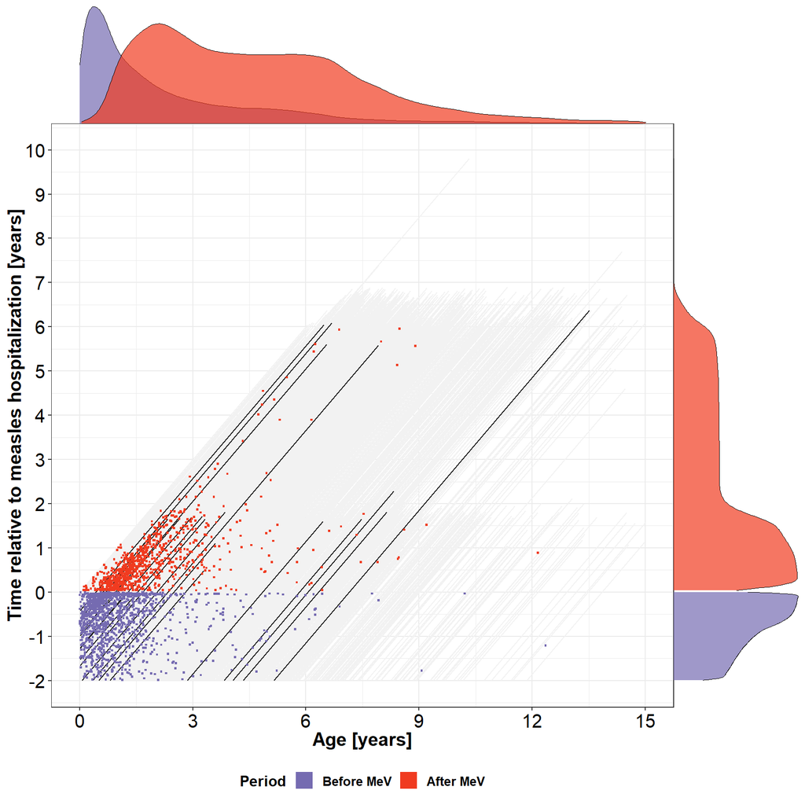

## Main analysis

- We fit the Poisson marginal model with cluster (patient), the current age (age.at.infection) and time after MeV

#### Table 2: Incidence rate ratio of hospital admission due to non-measles infectious disease between post-measles and pre-measles by time after measles

| Time after measles | Incidence rate ratio(95% CI) |
| --- | --- |
| 2 weeks | 3.16 95% CI( 2.12 , 4.7 ) |
| 3 weeks | 1.89 95% CI( 1.5 , 2.37 ) |
| 1 month | 1.07 95% CI( 0.86 , 1.33 ) |
| 2 months | 0.75 95% CI( 0.62 , 0.91 ) |
| 3 months | 0.83 95% CI( 0.68 , 1.02 ) |
| 6 months | 0.88 95% CI( 0.74 , 1.05 ) |
| 9 months | 0.8 95% CI( 0.66 , 0.97 ) |
| 1 year | 0.62 95% CI( 0.51 , 0.75 ) |
| 1.5 year | 0.49 95% CI( 0.39 , 0.62 ) |
| 2 years | 0.31 95% CI( 0.22 , 0.42 ) |
| 3 years | 0.08 95% CI( 0.05 , 0.15 ) |
| 4 years | 0.06 95% CI( 0.03 , 0.13 ) |
| 5 years | 0.11 95% CI( 0.06 , 0.2 ) |
| 5.5 years | 0.15 95% CI( 0.08 , 0.3 ) |
| 6 years | 0.22 95% CI( 0.1 , 0.47 ) |

#### Figure 2B: Incidence rate ratio of hospital admission due to non-measles infectious disease post vs. 2 year pre-measles

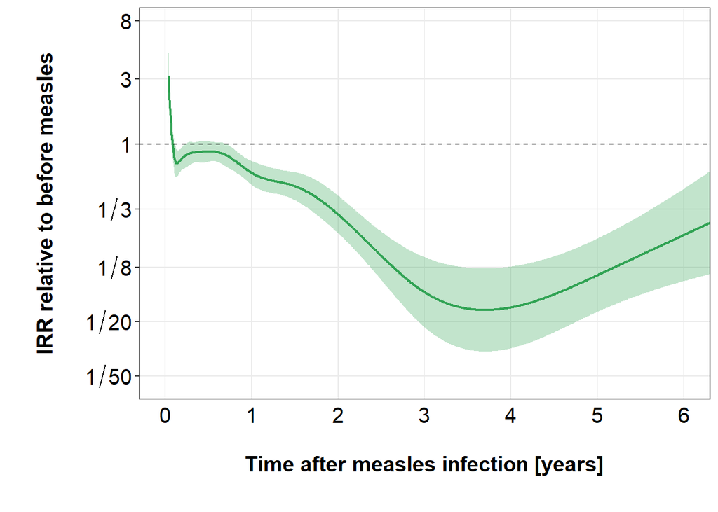

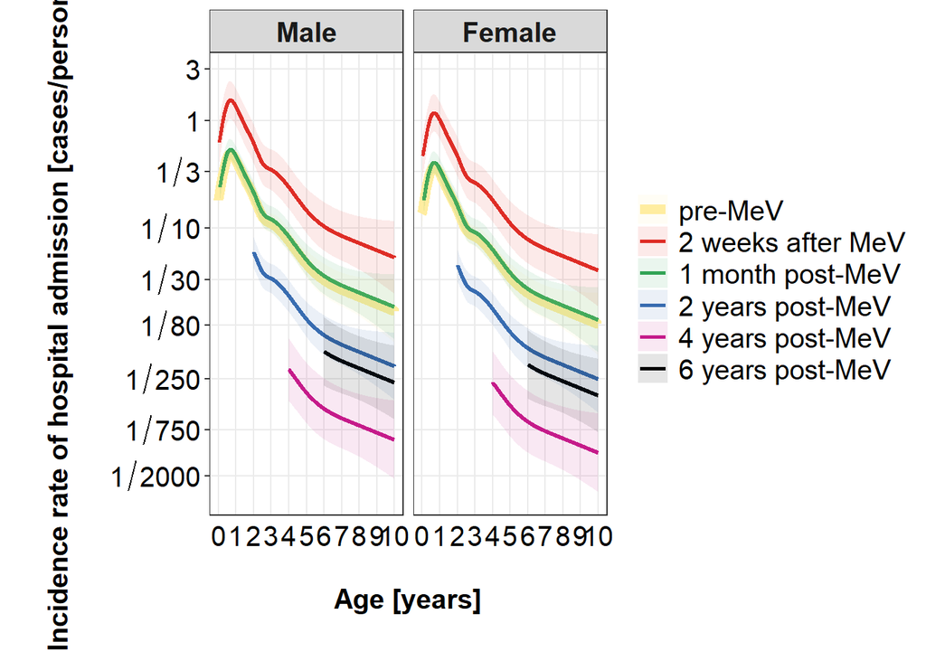

#### Figure 2C: Incidence rate difference of hopistal admission post-MeV vs. pre-MeV by age.

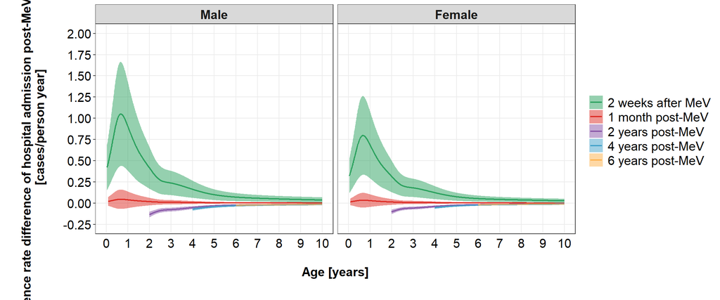

### Analysis with Interaction with age and sex and time since measles

- overall p.value= 0.255, p-value testing for interaction between age and time after MeV 0.137; between age and sex 0.355 and between time after MeV and sex 0.445

## Senstivity analysis

### Analysis 1

In this analysis, we allowed all patients who went home with discharge with presumably worse condition as alive.

#### Figure S1: Incidence rate ratio of hospital admission due to non-measles infectious disease post vs. 2 year pre-measles with patient outcome discharge with presumably worse condition were considered alive.

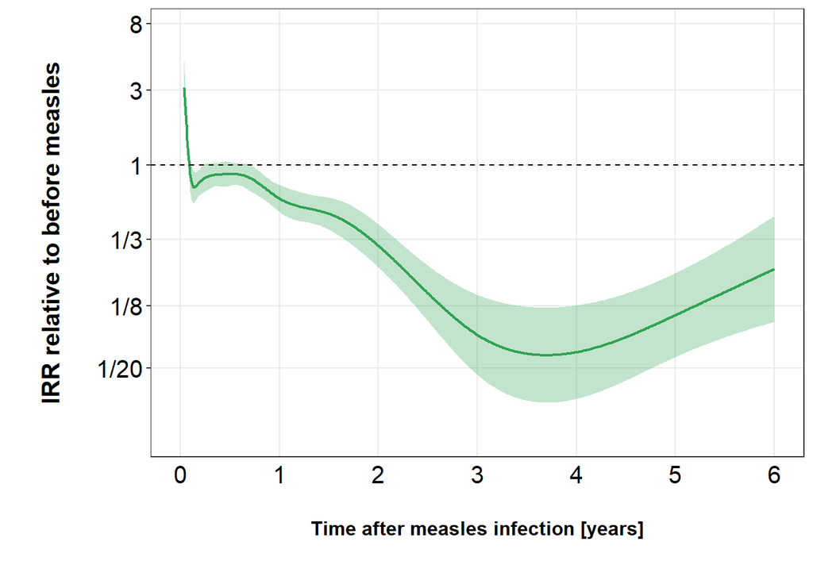

#### Table S2: Incidence rate ratio of hospital admission due to non-measles infectious disease between post-measles and pre-measles by time after measles

| Time after measles | Incidence rate ratio(95% CI) |
| --- | --- |
| 2 weeks | 3.13 95% CI( 2.1 , 4.66 ) |
| 3 weeks | 1.87 95% CI( 1.49 , 2.35 ) |
| 1 month | 1.06 95% CI( 0.86 , 1.32 ) |
| 2 months | 0.74 95% CI( 0.61 , 0.9 ) |
| 3 months | 0.82 95% CI( 0.67 , 1.01 ) |
| 6 months | 0.87 95% CI( 0.73 , 1.04 ) |
| 9 months | 0.79 95% CI( 0.66 , 0.96 ) |
| 1 year | 0.61 95% CI( 0.5 , 0.74 ) |
| 1.5 year | 0.49 95% CI( 0.39 , 0.62 ) |
| 2 years | 0.3 95% CI( 0.22 , 0.42 ) |
| 3 years | 0.08 95% CI( 0.05 , 0.15 ) |
| 4 years | 0.06 95% CI( 0.03 , 0.13 ) |
| 5 years | 0.11 95% CI( 0.06 , 0.2 ) |
| 5.5 years | 0.15 95% CI( 0.08 , 0.3 ) |
| 6 years | 0.22 95% CI( 0.1 , 0.47 ) |

### Analysis 2

#### Emigration population

In this sensitivity analysis, we simulate the emigration cases from the population since the last vists to the hospital with the mean emigration rate of HCMC is 0.0083 person year.

#### Figure S2: Predicted incidence rate ratio of hospital admission due to non-measles infectious disease post vs. 2 year pre-measles. The coefficients were estimated based on the Rubin’s rule and from data of 100 simulations.

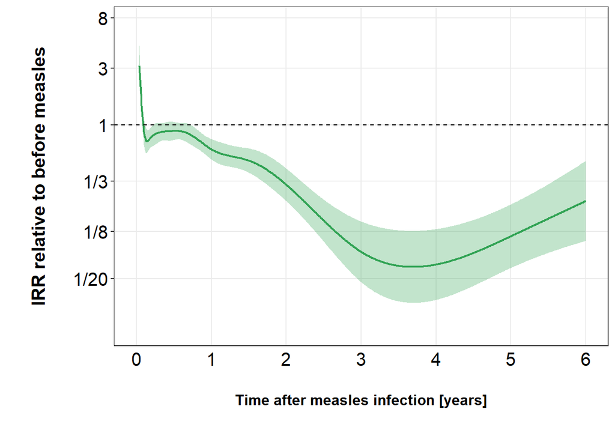

#### Table S.3: Incidence rate ratio of hospital admission due to non-measles infectious disease between post-measles and pre-measles by time after measles

| Time after measles | Incidence rate ratio(95% CI) |
| --- | --- |
| 2 weeks | 3.16 95% CI( 2.12 , 4.7 ) |
| 3 weeks | 1.89 95% CI( 1.5 , 2.37 ) |
| 1 month | 1.07 95% CI( 0.86 , 1.33 ) |
| 2 months | 0.75 95% CI( 0.62 , 0.91 ) |
| 3 months | 0.83 95% CI( 0.68 , 1.02 ) |
| 6 months | 0.89 95% CI( 0.74 , 1.06 ) |
| 9 months | 0.81 95% CI( 0.67 , 0.98 ) |
| 1 year | 0.62 95% CI( 0.51 , 0.76 ) |
| 1.5 year | 0.5 95% CI( 0.4 , 0.63 ) |
| 2 years | 0.31 95% CI( 0.23 , 0.43 ) |
| 3 years | 0.08 95% CI( 0.05 , 0.15 ) |
| 4 years | 0.07 95% CI( 0.03 , 0.13 ) |
| 5 years | 0.11 95% CI( 0.06 , 0.21 ) |
| 5.5 years | 0.16 95% CI( 0.08 , 0.31 ) |
| 6 years | 0.23 95% CI( 0.1 , 0.49 ) |

### Analysis 3

In this simulation study, we will vary the emigration rate from 0.01 to 0.15 to see when the second phase would disappear. Since the emigration is an independent process with the disease progression therefore it will introduce the noise to blurring the effect of time after MeV.

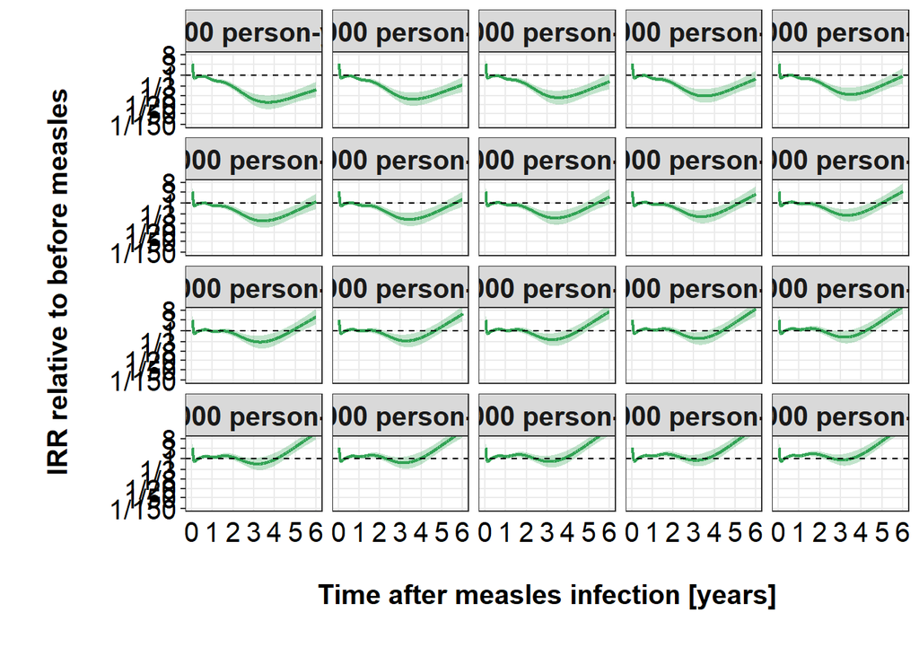

### Analysis 4

Subpopulation of children under 13 years old.

#### Figure S4: Incidence rate ratio of hospital admission due to non-measles infectious disease post vs. 2 year pre-measles with patient under 13 years old.

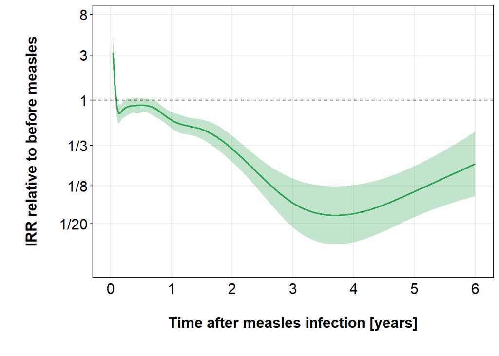

#### Table S4: Incidence rate ratio of hospital admission due to non-measles infectious disease between post-measles and pre-measles by time after measles

| Time after measles | Incidence rate ratio(95% CI) |
| --- | --- |
| 2 weeks | 3.16 95% CI( 2.12 , 4.7 ) |
| 3 weeks | 1.89 95% CI( 1.5 , 2.37 ) |
| 1 month | 1.07 95% CI( 0.86 , 1.33 ) |
| 2 months | 0.75 95% CI( 0.62 , 0.91 ) |
| 3 months | 0.83 95% CI( 0.68 , 1.02 ) |
| 6 months | 0.88 95% CI( 0.74 , 1.05 ) |
| 9 months | 0.8 95% CI( 0.66 , 0.97 ) |
| 1 year | 0.62 95% CI( 0.51 , 0.75 ) |
| 1.5 year | 0.49 95% CI( 0.39 , 0.62 ) |
| 2 years | 0.31 95% CI( 0.22 , 0.42 ) |
| 3 years | 0.08 95% CI( 0.05 , 0.15 ) |
| 4 years | 0.06 95% CI( 0.03 , 0.13 ) |
| 5 years | 0.11 95% CI( 0.06 , 0.2 ) |
| 5.5 years | 0.15 95% CI( 0.08 , 0.3 ) |
| 6 years | 0.21 95% CI( 0.1 , 0.47 ) |

### Supporting Data

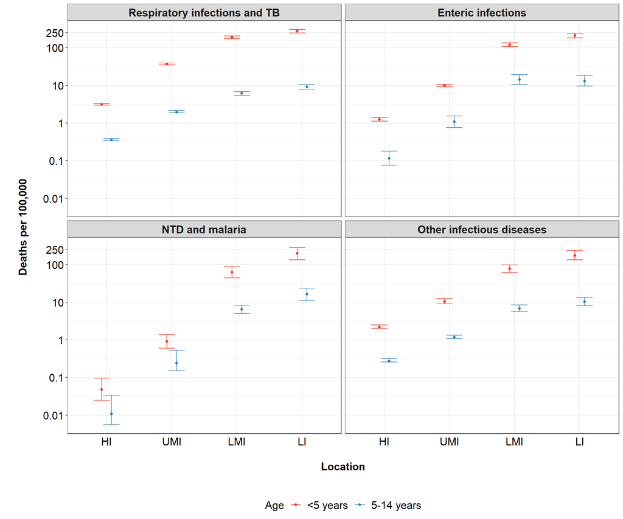

#### Figure S12: Global report on percent of total deaths due to infectious diseases in 2005 and 2015*.

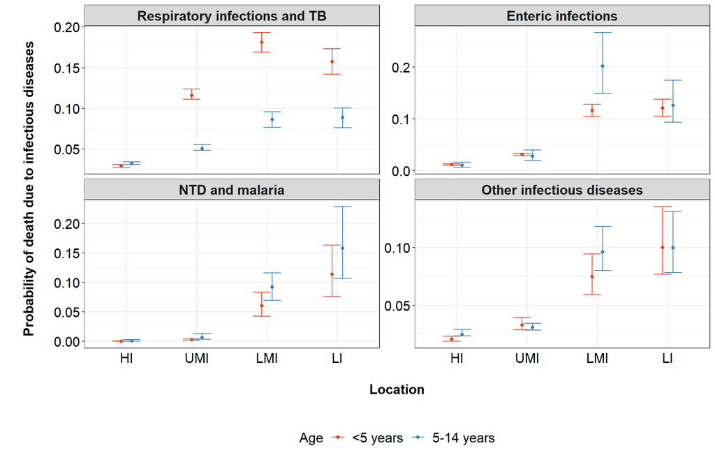

#### Figure S13: Incidence of hospitalization due to measles in HCMC.

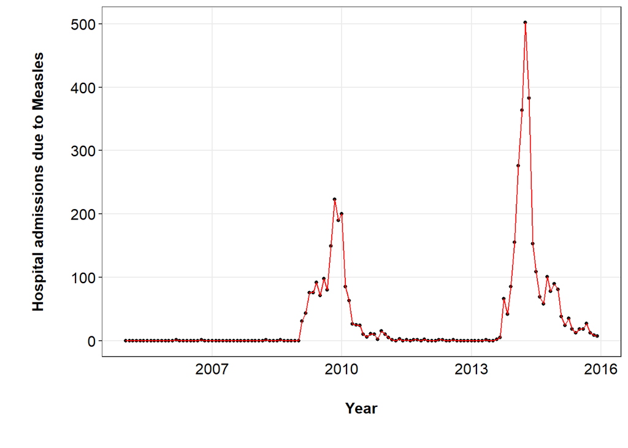

## Extra analysis

#### Figure S5: Piecewise constant hazard vs smooth hazard

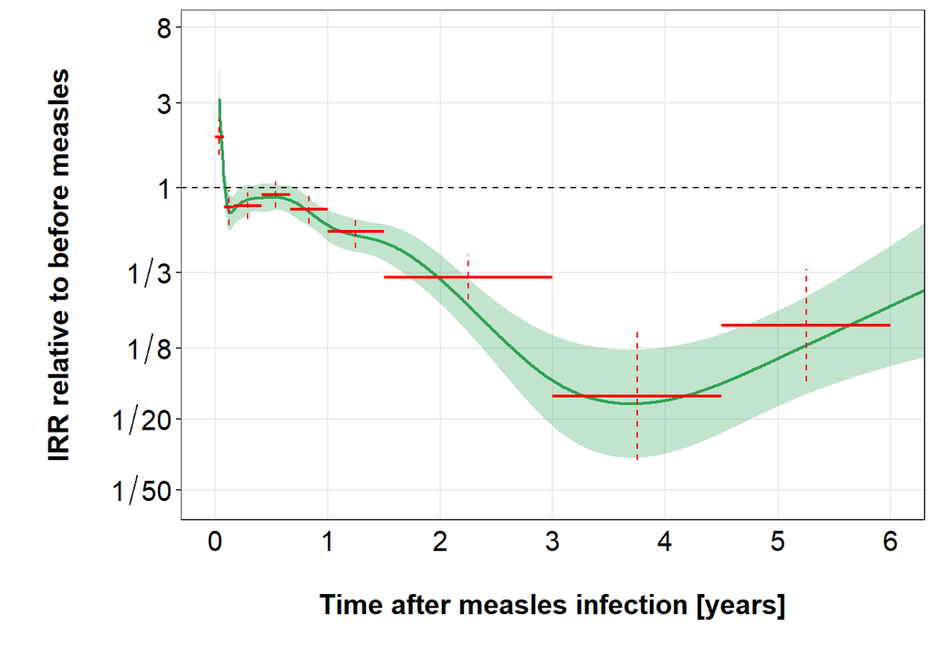

#### Figure S6: The effect of year on the incidence of hospital admission

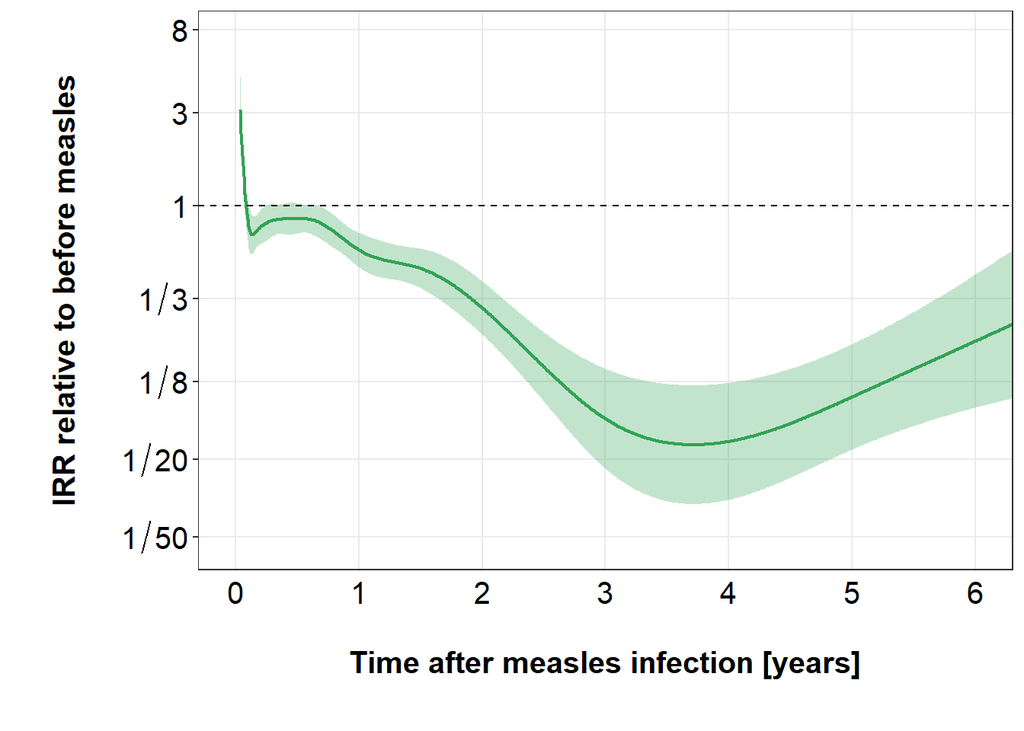

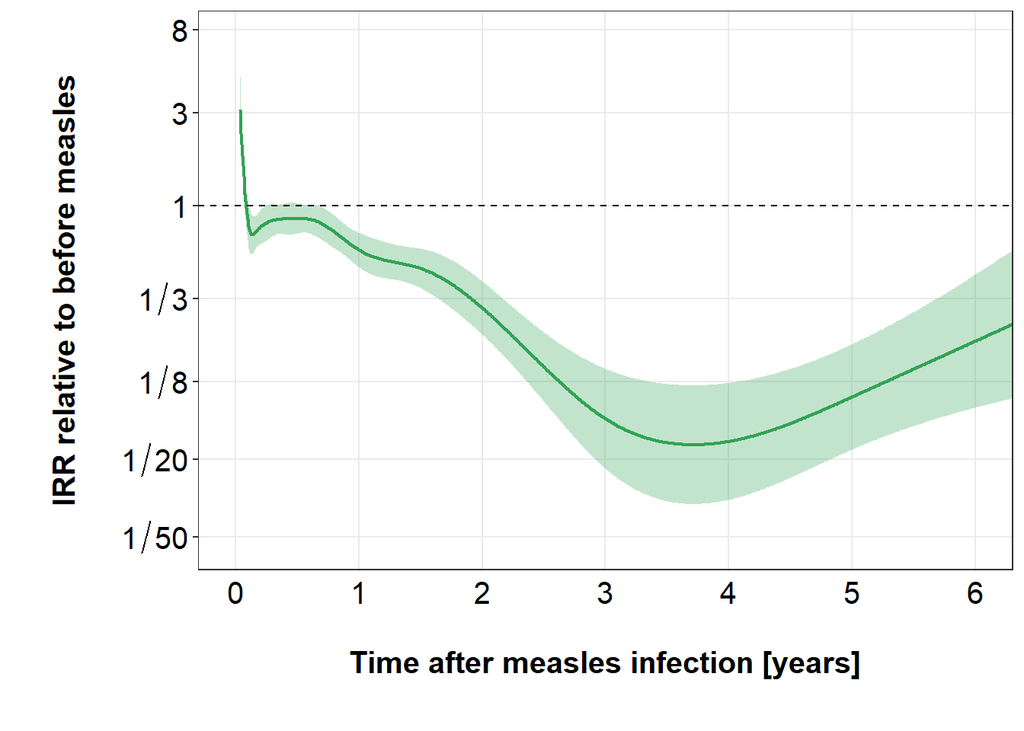

### Analysis 5: Subpopulation of children less than 4 years old with no longer than 2 years post-measles.

#### Figure S7: Incidence rate ratio of hospital admission due to non-measles infectious disease with children less than 4 years old with no longer than 2 years post-measles..

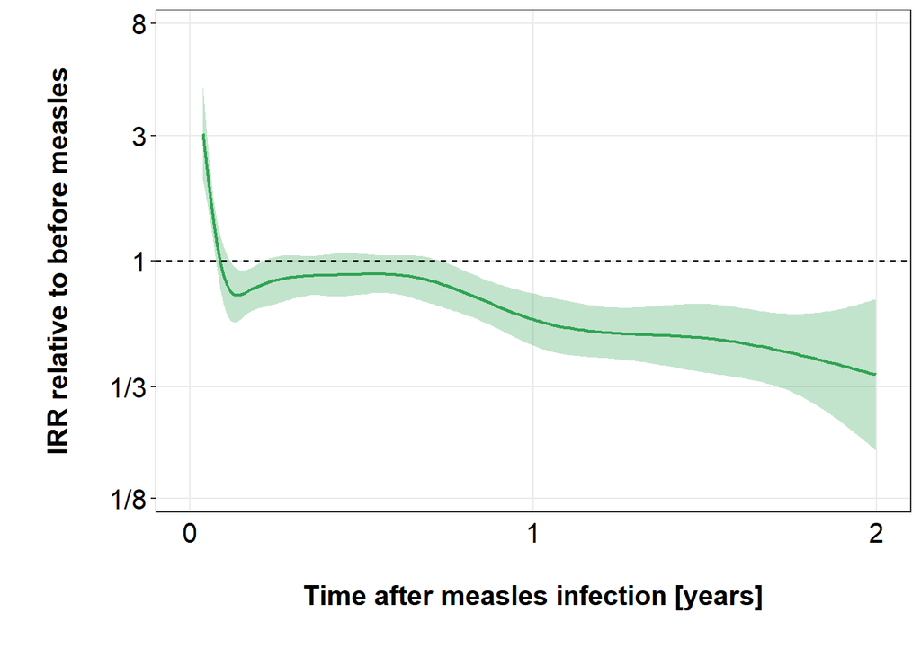

#### Figure S10

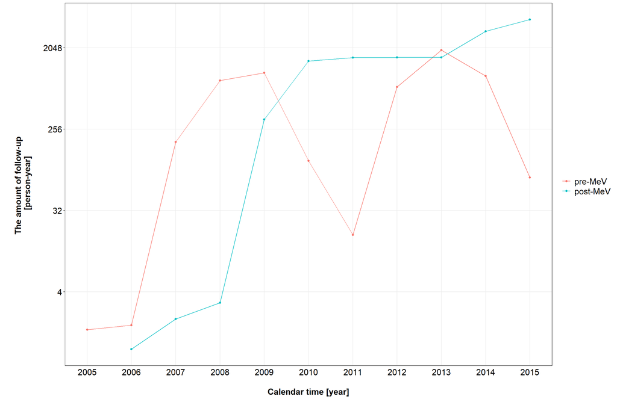

#### Assesment of overfitting of using splines to model the two time trends in the main model

- Model 1: we fix the number of knots of time but we remove one knots of age at infection
- Model 2: we fix the number of knots of age but we remove one knot of time post MeV

#### Figure S8: Incidence rate ratio of hospital admission due to non-measles infectious disease post vs. 2 year pre-measles (with 6 knots for age)

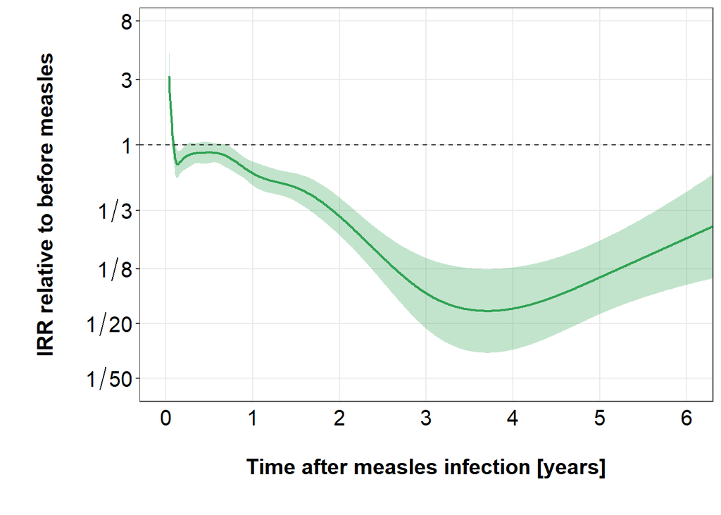

#### Figure S9: Incidence rate ratio of hospital admission due to non-measles infectious disease post vs. 2 year pre-measles (with 6 knots for times)

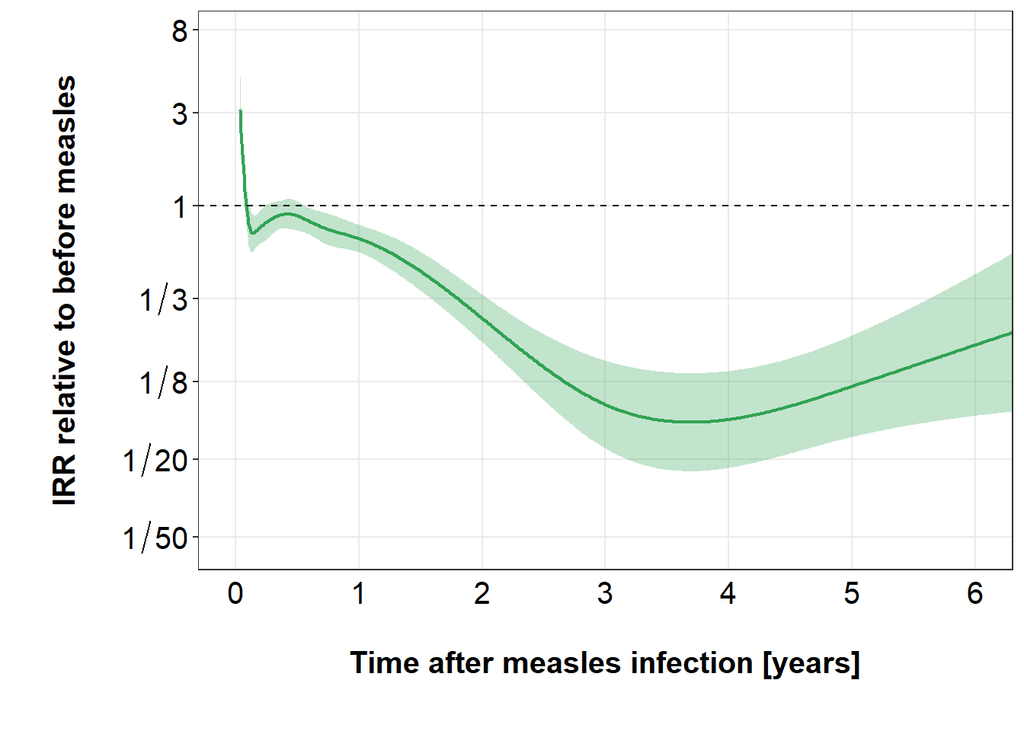